# Tutorial: Spatial Regression in R

Assessing Autocorrelation, Modeling Correlation Structures, and Spatial Autoregressive Models

Emil Bogs

# 1 Introduction

Welcome to this tutorial on spatial regression! Spatial data often violates the independence assumption of classical regression because observations close in space tend to be more similar than those far apart. This tutorial will guide you through:

- **Detecting spatial autocorrelation** using Moran’s I and semivariograms
- **Fitting basic regression models** and assessing residuals
- **Incorporating spatial correlation structures** into mixed-effects models
- **Comparing different spatial correlation models**
- **Evaluating model performance** and reporting findings

We’ll use vegetation data from the **sPlotOpen** database, focusing on European plant communities to understand how environmental factors influence species richness while accounting for spatial dependencies.

## 1.1 Learning Objectives

By the end of this tutorial, you will be able to:

1. Detect violations of independence due to spatial autocorrelation
2. Assess spatial autocorrelation in model residuals
3. Fit mixed-effects models with spatial correlation structures
4. Compare exponential, Gaussian, and spherical correlation structures
5. Evaluate and select optimal models using AIC and likelihood ratio tests
6. Interpret and report spatial regression results

### 1.1.1 Some Information on the Data-set Used

The data you’ll be working with in this computer lab comes from a project called [*sPlot*](https://www.idiv.de/en/sdiv/working_groups/wg_pool/splot/about_the_project.html), an initiative of the [German Centre for Integrative Biodiversity Research (iDiv)](https://www.idiv.de/en/index.html). The complete *sPlot* database covers a wide range of locations but has uneven coverage and is not publicly available. However, (Sabatini et al. 2021) addressed these issues by carefully selecting, organising, and obtaining permission from data owners of 105 different local and regional data-sets to make some of them open to the public. This led to the creation of **sPlotOpen**, the largest freely available collection of plot-based vegetation data. This data-set can be used to study global plant diversity, assist with remote sensing tasks, or track biodiversity changes over time.

*sPlotOpen* contains data from around the world. We use a European subset of the data for this session —sites with over ten species and sampling areas above 10m<sup>2</sup>. For each site, data includes species richness (number of different species per plot - `Species_richness`), location (longitude and latitude - `Longitude`,`Latitude`), country (`Country`), plot size (in square meters- `Releve_area`), geographical features (elevation, slope, aspect - `Elevation`, `Aspect`, and `Slope`), and environmental variables (loading on Principal Component axes 1 and 2 (`SoilClim_PC1`,`SoilClim_PC2`) based on climate and soil conditions derived by (Sabatini et al. 2021), and the [Environmental Stratification Class](https://www.wur.nl/en/research-results/research-institutes/environmental-research/projects/ebone/products/european-environmental-stratification.htm) - `Env.Strat`; derived by (Metzger et al. 2005)).

## 1.2 Essential Functions Reference

| Task | Function | Package |
| --- | --- | --- |
| Linear model | `lm()` | stats |
| GLS model | `gls()` | nlme |
| Mixed-effects model | `lme()` | nlme |
| Moran’s I | `Moran.I()` | ape |
| Moran’s I test | `moran.test()` | spdep |
| Moran plot | `moran.plot()` | spdep |
| Neighbors | `knn2nb()`, `knearneigh()` | spdep |
| Weights | `nb2listw()` | spdep |
| Variogram | `Variogram()` | nlme |
| Variogram | `variogram()` | gstat |
| Exponential correlation | `corExp()` | nlme |
| Gaussian correlation | `corGaus()` | nlme |
| Spherical correlation | `corSpher()` | nlme |
| Model comparison | `AIC()`, `anova()` | stats |
| Cross-validation | `train()`, `trainControl()` | caret |

# 2 Part 1: Data Preparation and Exploration

## 2.1 1.1 Load Required Packages

```r
# Load packages for spatial analysis
library(nlme)       # For mixed-effects models with spatial correlation
library(dplyr)      # For data manipulation
library(ggplot2)    # For visualization
library(sf)         # For simple features (spatial data)
library(spdep)      # For spatial weights and Moran's I
library(gstat)      # For geostatistics and variograms
library(ape)        # For phylogenetic statistics (includes Moran.I)
library(sp)         # For spatial classes
library(lmtest)     # For testing heteroscedasticity
library(caret)      # For k-fold validation
```

**HINT:** Packages needed are: `nlme`, `dplyr`, `ggplot2`, `sf`, `spdep`, `gstat`, `ape`, `sp`, `lmtest`,`caret`

## 2.2 1.2 Load and Explore the Data

```r
# Load the sPlot data
sPlot.Data <- read.csv("Splot_SppRichness.csv")
dim(sPlot.Data)
```

```
## [1] 872  16
```

```r
# Explore data structure
str(sPlot.Data)
```

```
## 'data.frame':    872 obs. of  16 variables:
##  $ X.2              : int  1 2 3 4 5 6 7 8 9 10 ...
##  $ X.1              : int  211 230 93 331 234 318 118 112 135 251 ...
##  $ X                : int  305 325 178 433 330 419 207 200 226 347 ...
##  $ PlotObservationID: int  215438 215501 210835 217879 215536 217738 213105 213085 213354 215593 ...
##  $ Species_richness : num  1.32 1.63 1.11 1.28 1.34 ...
##  $ Longitude        : num  11.1 11.1 14.6 12.8 11.1 ...
##  $ Latitude         : num  47 47 46.9 47.1 47 ...
##  $ Country          : chr  "Austria" "Austria" "Austria" "Austria" ...
##  $ Releve_area      : int  25 25 16 15 25 60 15 30 100 24 ...
##  $ Elevation        : num  2.15 1.95 1.4 2.36 2.77 ...
##  $ Aspect           : int  338 360 360 135 360 180 180 158 90 360 ...
##  $ Slope            : num  1.017 -0.44 -1.022 0.143 1.6 ...
##  $ SoilClim_PC1     : num  -2.57 -2.76 -1.73 -2.26 -2.76 ...
##  $ SoilClim_PC2     : num  6.38 6.53 4.41 4.74 6.53 ...
##  $ Env.Strat        : chr  "ALS" "ALS" "ALS" "ALS" ...
##  $ residuals        : num  -0.389 1.161 -1.367 -0.461 -0.231 ...
```

```r
# View summary statistics
summary(sPlot.Data)
```

```
##       X.2             X.1               X        PlotObservationID
##  Min.   :  1.0   Min.   :   6.0   Min.   :  79   Min.   : 202800
##  1st Qu.:218.8   1st Qu.: 739.2   1st Qu.:1474   1st Qu.: 347667
##  Median :436.5   Median :1441.5   Median :3155   Median : 941760
##  Mean   :436.5   Mean   :1452.0   Mean   :2881   Mean   : 765922
##  3rd Qu.:654.2   3rd Qu.:2157.5   3rd Qu.:4278   3rd Qu.:1055010
##  Max.   :872.0   Max.   :2900.0   Max.   :5374   Max.   :1107780
##  Species_richness   Longitude         Latitude       Country
##  Min.   :1.000    Min.   :-6.317   Min.   :35.04   Length:872
##  1st Qu.:1.255    1st Qu.: 8.894   1st Qu.:45.44   Class :character
##  Median :1.415    Median :13.554   Median :47.02   Mode  :character
##  Mean   :1.409    Mean   :13.491   Mean   :46.55
##  3rd Qu.:1.568    3rd Qu.:19.636   3rd Qu.:48.90
##  Max.   :1.959    Max.   :28.117   Max.   :70.36
##   Releve_area       Elevation            Aspect        Slope
##  Min.   :  12.0   Min.   :-1.57832   Min.   : 10   Min.   :-1.0224
##  1st Qu.:  25.0   1st Qu.:-0.84414   1st Qu.:135   1st Qu.:-0.8476
##  Median : 100.0   Median :-0.08127   Median :203   Median :-0.2648
##  Mean   : 149.2   Mean   : 0.00000   Mean   :212   Mean   : 0.0000
##  3rd Qu.: 200.0   3rd Qu.: 0.71252   3rd Qu.:315   3rd Qu.: 0.7259
##  Max.   :1200.0   Max.   : 3.19840   Max.   :360   Max.   : 4.2226
##   SoilClim_PC1      SoilClim_PC2     Env.Strat           residuals
##  Min.   :-3.1930   Min.   :-1.198   Length:872         Min.   :-2.28067
##  1st Qu.:-1.8970   1st Qu.: 1.575   Class :character   1st Qu.:-0.68918
##  Median :-1.0600   Median : 3.255   Mode  :character   Median : 0.03934
##  Mean   :-0.9886   Mean   : 3.098                      Mean   : 0.00000
##  3rd Qu.:-0.2417   3rd Qu.: 4.728                      3rd Qu.: 0.77300
##  Max.   : 1.9330   Max.   : 8.164                      Max.   : 2.86242
```

```r
# Check the first few rows
head(sPlot.Data)
```

```
##   X.2 X.1   X PlotObservationID Species_richness Longitude Latitude Country
## 1   1 211 305            215438         1.322219  11.08823 47.04537 Austria
## 2   2 230 325            215501         1.633468  11.08279 47.03833 Austria
## 3   3  93 178            210835         1.113943  14.64975 46.87335 Austria
## 4   4 331 433            217879         1.278754  12.83430 47.08117 Austria
## 5   5 234 330            215536         1.342423  11.10465 47.04072 Austria
## 6   6 318 419            217738         1.531479  12.73256 47.08501 Austria
##   Releve_area Elevation Aspect      Slope SoilClim_PC1 SoilClim_PC2 Env.Strat
## 1          25  2.153263    338  1.0173240       -2.572        6.382       ALS
## 2          25  1.947180    360 -0.4396240       -2.757        6.532       ALS
## 3          16  1.402531    360 -1.0224032       -1.726        4.409       ALS
## 4          15  2.359346    135  0.1431552       -2.260        4.735       ALS
## 5          25  2.771513    360  1.6001032       -2.757        6.532       ALS
## 6          60  1.991340    180  0.7259344       -2.764        5.274       ALS
##    residuals
## 1 -0.3885900
## 2  1.1614193
## 3 -1.3666289
## 4 -0.4613393
## 5 -0.2306448
## 6  0.7202046
```

**TASK:** Fill in functions to read CSV files, examine structure, summarize, and view the first rows.

## 2.3 1.3 Data Cleaning and Standardization

```r
# Remove missing values
sPlot.Data <- na.omit(sPlot.Data)
dim(sPlot.Data)
```

```
## [1] 872  16
```

```r
# Standardize continuous predictors
sPlot.Data$Elevation <- scale(sPlot.Data$Elevation)
sPlot.Data$Slope <- scale(sPlot.Data$Slope)
```

**TASK:** Fill in the function to remove NAs and the function to standardize variables (z-scores).

## 2.4 1.4 Visualize Spatial Distribution

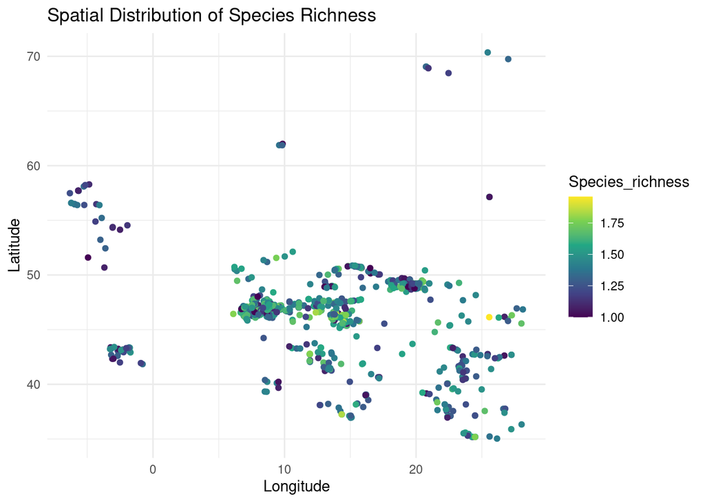

```r
# Create a basic spatial plot of species richness
ggplot(sPlot.Data) +
  geom_point(aes(x = Longitude, y = Latitude, color = Species_richness)) +
  scale_color_viridis_c() +
  theme_minimal() +
  labs(title = "Spatial Distribution of Species Richness",
       x = "Longitude", y = "Latitude")
```

**TASK:** Fill in the geom function for points and the aesthetic mappings (x, y, color).

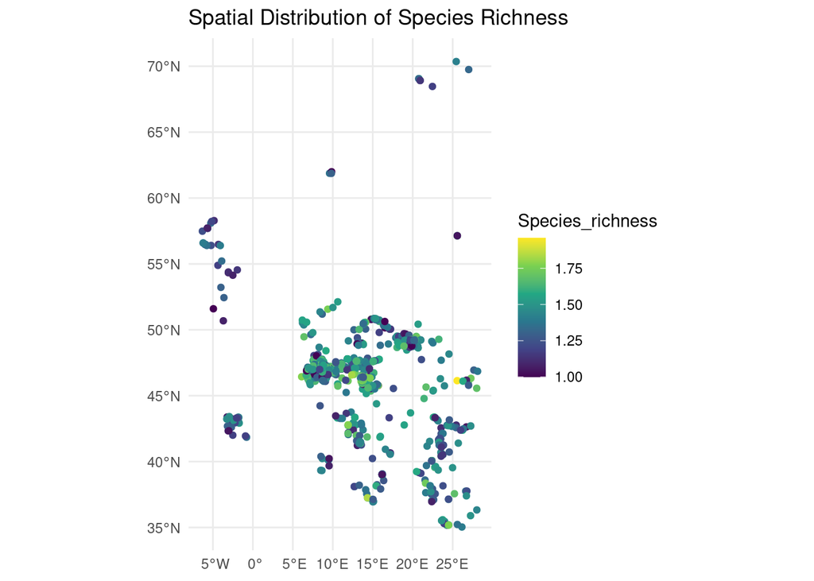

```r
# Convert to sf object for better spatial visualization
data_sf <- st_as_sf(x = sPlot.Data,
                 coords = c("Longitude", "Latitude"),
                 crs = 4326)

# Plot using geom_sf
ggplot(data_sf) +
  geom_sf(aes(color = Species_richness)) +
  scale_color_viridis_c() +
  theme_minimal() +
  labs(title = "Spatial Distribution of Species Richness")
```

**TASK:** Fill in the function to create sf objects, its arguments (x, coords, crs), coordinate column names, and the geom for sf objects.

# 3 Part 2: Detecting Spatial Autocorrelation

## 3.1 2.1 Understanding Spatial Autocorrelation Concepts

**Key Concepts:**

- **Spatial Autocorrelation**: The correlation of a variable with itself through space
  - *Positive*: Similar values cluster together (high near high, low near low)
  - *Negative*: Dissimilar values are neighbors (high near low)
  - *Zero*: Random spatial pattern
- **Moran’s I**: Quantifies spatial autocorrelation
  - Ranges from -1 (dispersion) to +1 (clustering)
  - Values near 0 suggest randomness
- **Semivariogram**: Shows how similarity decreases with distance
  - *Nugget*: Variability at zero distance (measurement error)
  - *Range*: Distance where correlation diminishes
  - *Sill*: Plateau indicating total variance

## 3.2 2.2 Calculate Moran’s I

### 3.2.1 Method 1: Using the `ape` package

```r
# Create coordinate matrix
coords <- cbind(sPlot.Data$Longitude, sPlot.Data$Latitude)

# Calculate distance matrix
dist_matrix <- as.matrix(dist(coords))

# Create inverse distance weight matrix
inv_dist_matrix <- 1 / dist_matrix
diag(inv_dist_matrix) <- 0  # Set diagonal to 0

# Calculate Moran's I using ape
library(ape)
moran_result <- Moran.I(x = sPlot.Data$Species_richness,
                      weight = inv_dist_matrix,
                      scaled = TRUE,
                      na.rm = TRUE)

# Display results
print(moran_result)
```

```
## $observed
## [1] 0.1239057
##
## $expected
## [1] -0.001148106
##
## $sd
## [1] 0.01192406
##
## $p.value
## [1] 0
```

**TASK:** Fill in functions to combine columns, calculate distances, and compute Moran’s I with appropriate arguments.

### 3.2.2 Method 2: Using the `spdep` package

```r
# Create neighbor structure (4 nearest neighbors)
library(spdep)
nb <- knn2nb(knearneigh(coords, k = 4))

# Create spatial weights list
listw <- nb2listw(neighbours = nb, style = "W")

# Compute Moran's I test
moran.test(x = sPlot.Data$Species_richness,
          listw = listw)
```

```
##
##  Moran I test under randomisation
##
## data:  sPlot.Data$Species_richness
## weights: listw
##
## Moran I statistic standard deviate = 10.579, p-value < 2.2e-16
## alternative hypothesis: greater
## sample estimates:
## Moran I statistic       Expectation          Variance
##      0.2297657886     -0.0011481056      0.0004764547
```

**TASK:** Fill in functions to create k-nearest neighbors, convert to neighbor list, create weights, and perform Moran’s test.

## 3.3 2.3 Visualize Moran’s I with a Moran Plot

A Moran scatterplot showing relationship between a variable and the average value of its neighbors for the same variable It is instructive to consider each quadrant of the plot. In the upper-right quadrant are cases where both the value and local average value of the attribute are higher than the overall average value. Similarly, in the lower-left quadrant are cases where both the value and local average value of the attribute are lower than the overall average value. These cases confirm positive spatial autocorrelation. Cases in the other two quadrants indicate negative spatial autocorrelation. Depending on which groups are dominant, there will be an overall tendency towards positive or negative (or perhaps no) spatial autocorrelation.

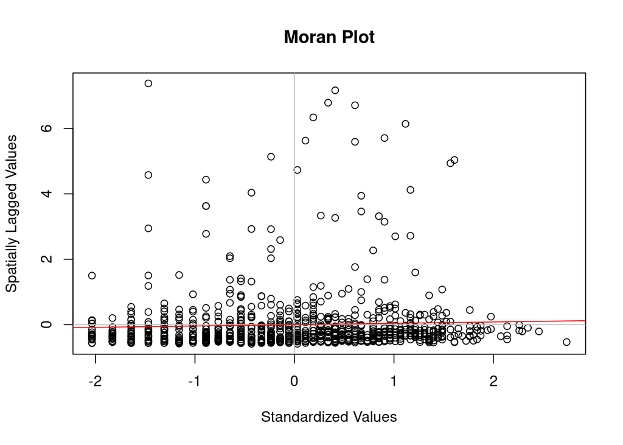

```r
# Create Moran plot data manually (using ape approach)
DataMoranPlot <- data.frame(
  LaggedValues = scale(as.numeric(inv_dist_matrix %*% sPlot.Data$Species_richness)),
  StandardizedValues = scale(sPlot.Data$Species_richness)
)

# Create Moran plot
plot(LaggedValues ~ StandardizedValues,
     data = DataMoranPlot,
     main = "Moran Plot",
     xlab = "Standardized Values",
     ylab = "Spatially Lagged Values")
abline(h = 0, v = 0, col = "gray")
abline(lm(LaggedValues ~ StandardizedValues, data = DataMoranPlot),
       col = "red")
```

**TASK:** Fill in the formula notation for the plot and the function to fit a linear model.

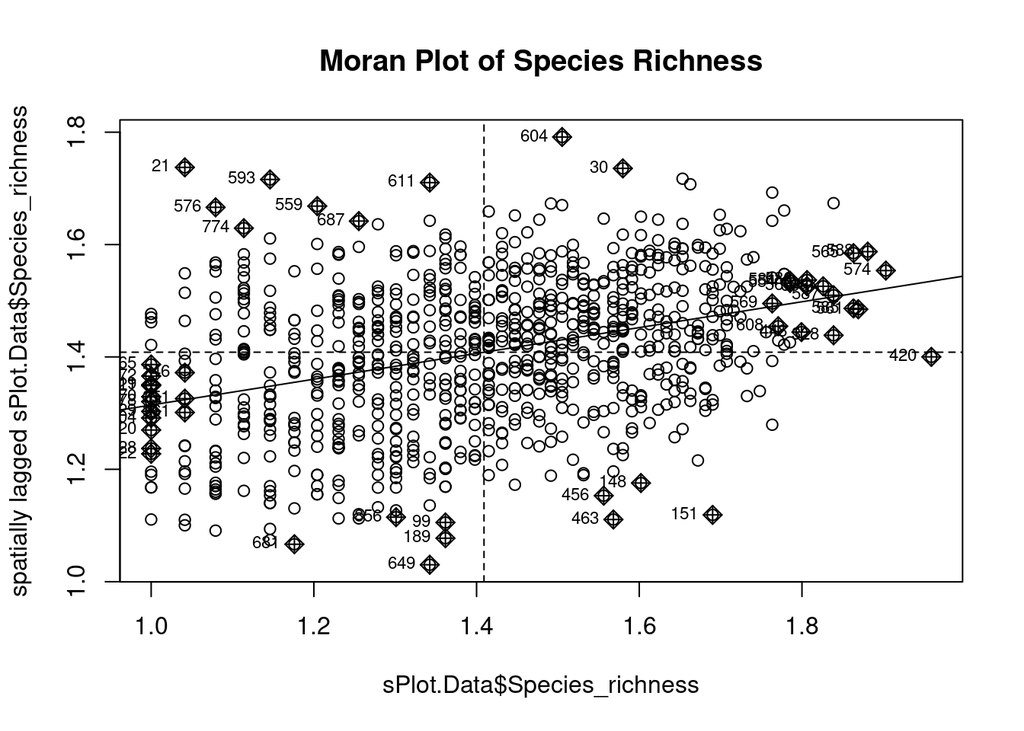

```r
# Moran plot using spdep
moran.plot(x = sPlot.Data$Species_richness,
          listw = listw,
          main = "Moran Plot of Species Richness")
```

**TASK:** Fill in the function and arguments for creating a Moran plot.

## 3.4 2.4 Interpret Moran’s I Results

**Your Interpretation:**

- Moran I Statistic: 0.2297657886 (fill in the value from your output)
- P-value: 2.2e-16 (fill in the value)
- Conclusion: Is there significant spatial autocorrelation? YES (Yes/No)
- Type: Is it positive or negative autocorrelation? Positive
- Implication: What does this mean for your analysis? The data is slightly clustered.

# 4 Part 3: Basic Linear Regression and Residual Analysis

## 4.1 3.1 Fit a Basic Linear Model

```r
# Fit linear model without spatial components
lm_model <- lm(Species_richness ~ Elevation + Slope + SoilClim_PC1 + SoilClim_PC2,
                  data = sPlot.Data)

# View model summary
View(lm_model)
```

[output not shown]

**TASK:** Fill in the function to fit linear models, the response variable, and the dataset.

## 4.2 3.2 Diagnostic Plots

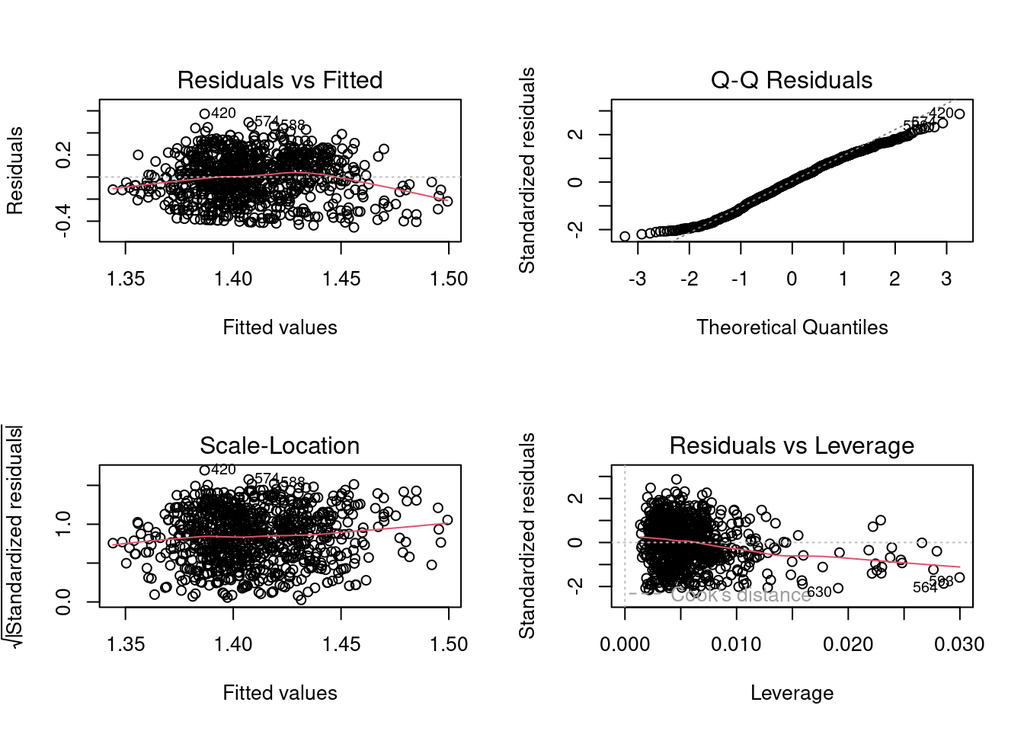

```r
# Create diagnostic plots
par(mfrow = c(2, 2))
plot(lm_model)
```

**TASK:** Fill in the function to create diagnostic plots.

## 4.3 3.3 Test for Heteroscedasticity

A formal statistical test you can use to determine if heteroscedasticity is present is the Breusch-Pagan test. The test uses the following null and alternative hypotheses:

- Null Hypothesis (H0): Homoscedasticity is present (the residuals are distributed with equal variance)
- Alternative Hypothesis (HA): Heteroscedasticity is present (the residuals are not distributed with equal variance)

If the $p$-value of the test is less than some significance level (i.e. $\alpha$ = 0.05) then we reject the null hypothesis and conclude that heteroscedasticity is present in the regression model.

```r
# Breusch-Pagan test for heteroscedasticity
library(lmtest)
bptest(lm_model)
```

```
##
##  studentized Breusch-Pagan test
##
## data:  lm_model
## BP = 20.243, df = 4, p-value = 0.0004471
```

**TASK:** Fill in the function to perform the Breusch-Pagan test.

## 4.4 3.4 Test Residuals for Spatial Autocorrelation

```r
# Extract residuals
lm_residuals <- residuals(lm_model)

# Moran's I on residuals (using ape)
Moran.I(x = lm_residuals,
     weight = inv_dist_matrix,
     scaled = TRUE,
     na.rm = TRUE)
```

```
## $observed
## [1] 0.1201902
##
## $expected
## [1] -0.001148106
##
## $sd
## [1] 0.01192361
##
## $p.value
## [1] 0
```

```r
# Moran's I on residuals (using spdep)
moran.test(x = lm_residuals,
          listw = listw)
```

```
##
##  Moran I test under randomisation
##
## data:  lm_residuals
## weights: listw
##
## Moran I statistic standard deviate = 10.427, p-value < 2.2e-16
## alternative hypothesis: greater
## sample estimates:
## Moran I statistic       Expectation          Variance
##      0.2264508204     -0.0011481056      0.0004764183
```

**TASK:** Fill in functions to extract residuals and compute Moran’s I on residuals.